# PS 7

## Q1: Build a model to predict average systolic blood pressure using combination of Age, Gender, Height and Weight

```r
library(NHANES)
data = NHANESraw
data = data[,c("BPSysAve","Age","Weight","Height", "WTMEC2YR","Gender")]
```

Renaming the attribute WTMEC2YR as Survey_Weights

```r
colnames(data)[5] = "Survey_Weights"
```

```r
head(data)
```

| BPSysAve | Age | Weight | Height | Survey_Weights | Gender |
| --- | --- | --- | --- | --- | --- |
| 113 | 34 | 87.4 | 164.7 | 81528.77 | male |
| NA | 4 | 17.0 | 105.4 | 56995.04 | male |
| 109 | 16 | 72.3 | 181.3 | 14509.28 | male |
| 93 | 10 | 39.8 | 147.8 | 12041.64 | male |
| 150 | 60 | 116.8 | 166.0 | 21000.34 | female |
| 104 | 26 | 97.6 | 173.0 | 22633.58 | male |

```r
sapply(data, function(x) sum(is.na (x)))
```

**BPSysAve**

5426

**Age**

0

**Weight**

888

**Height**

2258

**Survey_Weights**

0

**Gender**

0

There are 5426 missing values in the Average Systolic Blood Pressure field. We drop all the misssing values because it is difficult to create models with NAs.

```r
data = data[complete.cases(data),]
sapply(data, function(x) sum(is.na (x)))
dim(data)
```

**BPSysAve**

0

**Age**

0

**Weight**

0

**Height**

0

**Survey_Weights**

0

**Gender**

0

1. 14720

2. 6

After removing all the missing values, we still have 14,720 rows for analysis.

Since WTMEC2YR represents a segment of population sharing the same values and not an individual, this variable needs to be standardized.

```r
total_weights = sum(data$Survey_Weights)
data$Survey_Weights = data$Survey_Weights/total_weights
head(data)
```

|  | BPSysAve | Age | Weight | Height | Survey_Weights | Gender |
| --- | --- | --- | --- | --- | --- | --- |
| 1 | 113 | 34 | 87.4 | 164.7 | 1.578139e-04 | male |
| 3 | 109 | 16 | 72.3 | 181.3 | 2.808538e-05 | male |
| 4 | 93 | 10 | 39.8 | 147.8 | 2.330880e-05 | male |
| 5 | 150 | 60 | 116.8 | 166.0 | 4.065002e-05 | female |
| 6 | 104 | 26 | 97.6 | 173.0 | 4.381146e-05 | male |
| 7 | 112 | 49 | 86.7 | 168.4 | 1.434583e-04 | female |

Let's explore the relationship between Age, Height, Weight, Gender and Avg. Systolic Blood Pressure.

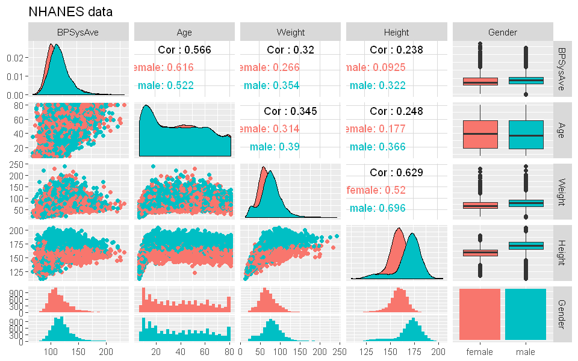

```r
library(repr)
options(repr.plot.width = 8, repr.plot.height = 5)
library(GGally)
ggpairs(data = data[, -5], title="NHANES data", mapping = ggplot2::aes(colour = Gender))
```

Since we are dealing with multiple variables, we need to split the variables into different zones to properly understand the underlying trends.

```r
Age = data$Age
Weight = data$Weight
Height = data$Height

Age.cat = rep(NA, nrow(data))
Age.cat[Age <= quantile(Age, 1/3)] = "Young"
Age.cat[Age > quantile(Age, 1/3) & Age <= quantile(Age, 2/3)] = "Medium Age"
Age.cat[Age > quantile(Age, 2/3)] = "Old"
Age.cat = factor(Age.cat, levels = c("Young", "Medium Age", "Old Age"))

Weight.cat = rep(NA, nrow(data))
Weight.cat[Weight <= quantile(Weight, 1/3)] = "Light"
Weight.cat[Weight > quantile(Weight, 1/3) & Weight <= quantile(Weight, 2/3)] = "Medium Weight"
Weight.cat[Weight > quantile(Weight, 2/3)] = "Heavy"
Weight.cat = factor(Weight.cat, levels = c("Light", "Medium Weight", "Heavy"))

Height.cat = rep(NA, nrow(data))
Height.cat[Height <= quantile(Height, 1/3)] = "Short"
Height.cat[Height > quantile(Height, 1/3) & Height <= quantile(Height, 2/3)] = "Medium Height"
Height.cat[Height > quantile(Height, 2/3)] = "Tall"
Height.cat = factor(Height.cat, levels = c("Short", "Medium Height", "Tall"))

data.cat = data.frame(data, Age.cat, Weight.cat, Height.cat)
```

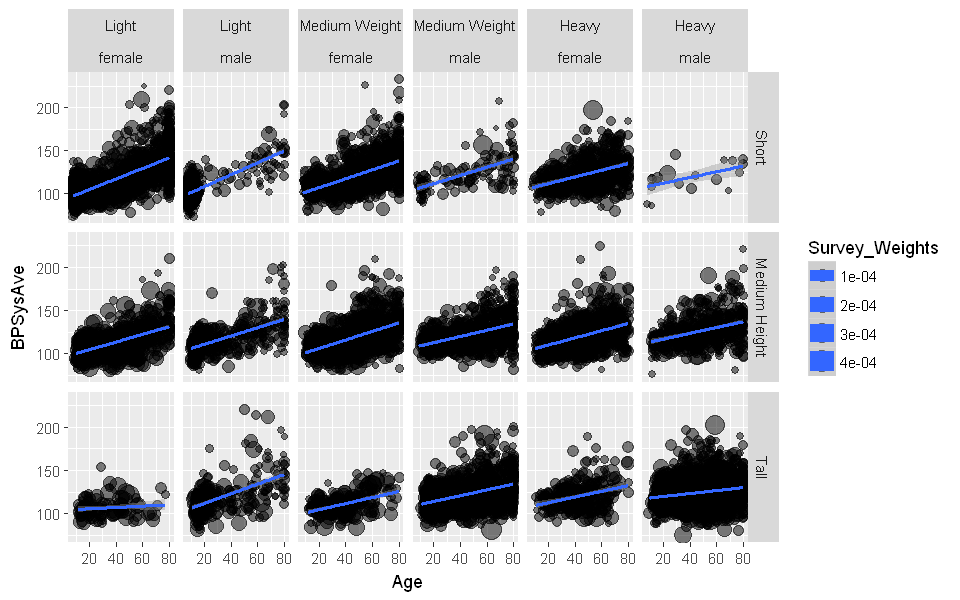

```r
library(ggplot2)
ggplot(data.cat, aes(x = Age, y = BPSysAve, size = Survey_Weights)) + geom_point(alpha = 0.5) +
geom_smooth(span = 1, method = lm) +
facet_grid(Height.cat~ Weight.cat + Gender)
```

There is sparsity of data in a few specific regions. Also, it can be seen from the above graph that there is an underlying linear trend in the data. Hence it seems appropriate to explain the relationship among these variable with a linear model.

```r
data.lm = lm(BPSysAve ~ Age + Weight + Height + Gender, data = data, weights = Survey_Weights)
lm.grid = expand.grid(Age = seq(10, 80, 10), Height = seq(120, 200, 20),
                    Weight = seq(20, 220, 55),
                     Gender = c("female", "male"))
data.predict = predict(data.lm, newdata = lm.grid)
data.df = data.frame(lm.grid, fit = as.vector(data.predict))
```

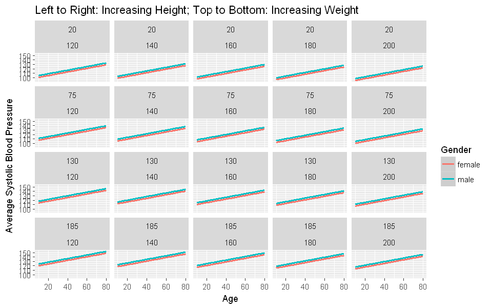

```r
ggplot(data.df, aes(x = Age, y = fit, color = Gender)) + geom_smooth() + facet_wrap(~ Weight + Height) +
ggtitle('Left to Right: Increasing Height; Top to Bottom: Increasing Weight') + ylab('Average Systolic Blood Pressure')
```

It can be clearly observed that there aren't any awkwards trends prevalant in the data.

As you go move from top to bottom i.e with increasing weights, the avg blood pressure increases for both male and female.

Also as you move from left to right, i.e. with increasing heights, the avg blood pressure appears to reduce a bit.

It can be seen from the graph that both men and women who are short and heavy seem to have the highest average systolic blood pressure which sounds very practical too.

In general, in every zone i.e. for a particular height, weight and age, men seem to have greater bllod pressure when compared with women.

## Q2: Predicting Diabetes using a combination of Age, Gender, Height and Weight as explanatories.

```r
Diab = NHANESraw[,c("BPSysAve","Age","Weight","Height", "WTMEC2YR","Gender", "Diabetes")]
```

```r
Diab = Diab[complete.cases(Diab),]
sapply(Diab, function(x) sum(is.na (x)))
dim(Diab)
```

**BPSysAve**

0

**Age**

0

**Weight**

0

**Height**

0

**WTMEC2YR**

0

**Gender**

0

**Diabetes**

0

1. 14713

2. 7

```r
Diab$Diabetes = as.numeric(Diab$Diabetes)
Diab$Diabetes = Diab$Diabetes - 1
```

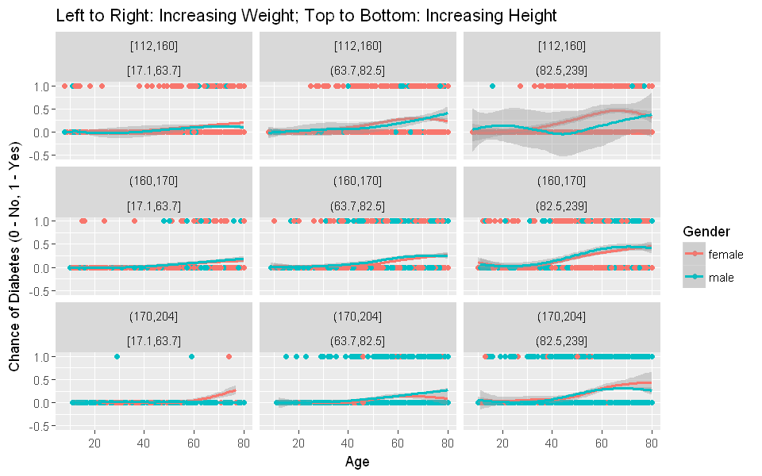

```r
ggplot(Diab, aes(x = Age, y = Diabetes, color = Gender)) + geom_point() +
geom_smooth(method = "loess") +
facet_wrap(~(cut_number(Height, n = 3)) + ~(cut_number(Weight,n = 3))) +
ggtitle('Left to Right: Increasing Weight; Top to Bottom: Increasing Height') +
ylab('Chance of Diabetes (0 - No, 1 - Yes)')
```

In general, it can be observed that as the Weight increases, the chance of being diabetic also increase.

There are very few data points for male in the region with low height and heavy weight. Likewise, there are only few points for females who are tall and heavy.

Also, it can be observed that people over the age of 40 are more prone to diabetic.

It can also be deduced from the above graph that the model to predict diabetes needs Age, Weight, Height and Gender to be taken into consideration.

```r
head(Diab)
```

| BPSysAve | Age | Weight | Height | WTMEC2YR | Gender | Diabetes |
| --- | --- | --- | --- | --- | --- | --- |
| 113 | 34 | 87.4 | 164.7 | 81528.77 | male | 0 |
| 109 | 16 | 72.3 | 181.3 | 14509.28 | male | 0 |
| 93 | 10 | 39.8 | 147.8 | 12041.64 | male | 0 |
| 150 | 60 | 116.8 | 166.0 | 21000.34 | female | 1 |
| 104 | 26 | 97.6 | 173.0 | 22633.58 | male | 0 |
| 112 | 49 | 86.7 | 168.4 | 74112.49 | female | 0 |

```r
Diab.glm = glm(Diabetes ~ Age + Weight + Height + Gender, data = Diab, family = "binomial")
glm.grid = expand.grid(Age = seq(10, 80, 10), Height = seq(120, 200, 20),
                    Weight = seq(20, 220, 55),
                     Gender = c("female", "male"))
Diab.predict = predict(Diab.glm, newdata = glm.grid, type = "response")
Diab.df = data.frame(glm.grid, fit = as.vector(Diab.predict))
```

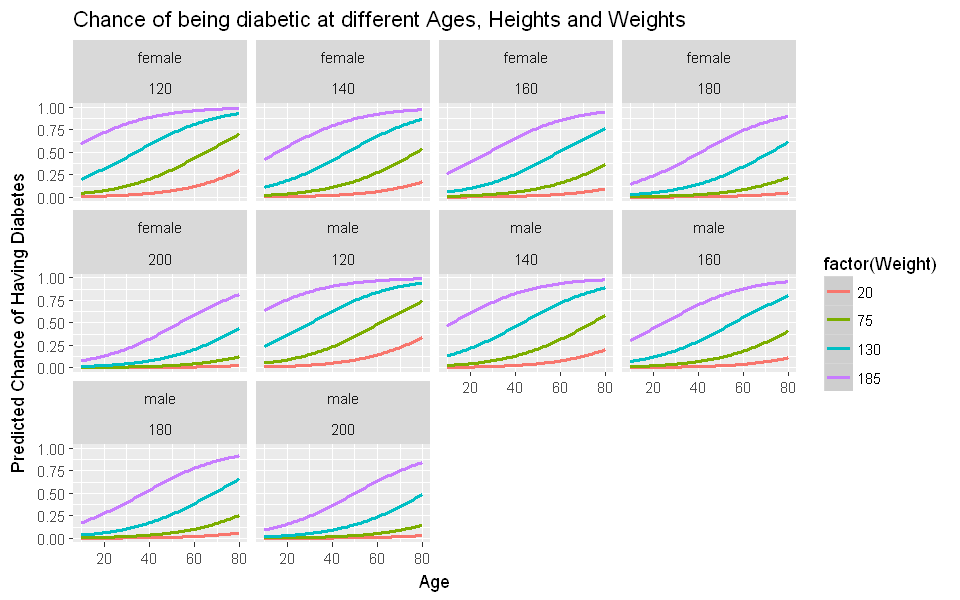

```r
ggplot(Diab.df, aes(x = Age, y = fit, color = factor(Weight))) + geom_smooth() +
facet_wrap(~ Gender + Height) +
ggtitle('Chance of being diabetic at different Ages, Heights and Weights') +
ylab('Predicted Chance of Having Diabetes')
```

It can observed that People who are heavy are more prone to being diabetic in general.

The chance of being diabetic clearly has an increasing trend with age.

Among the people who are heavy, both male and female, the shorter ones have a stronger tendency to being diabetic than the taller people which also sounds practically plausible.

With the increasing weight the chance of being diabetic clearly increases but it has a slightly downward trend with both weight and Height simultaneously increasing.

Also in order to enhance the visual appeal of the graphs, it appears wise to factor on weights than on heights since weights appear to have a stronger influence on the chance of being diabetic than Height.

## Q3: Diabetes prediction using explanatories Age, Weight, Height, Gender and Sleep Hours during Night

Diabetes is usually associated with disturbed sleeping patterns in real life, so I choose Sleep hours variable to explore the relationship between sleep duration and chance of being Diabetic

```r
Diab2 = NHANESraw[,c("Age","Weight","Height", "WTMEC2YR","Gender", "Diabetes", "SleepHrsNight")]
```

```r
Diab2 = Diab2[complete.cases(Diab2),]
sapply(Diab2, function(x) sum(is.na (x)))
dim(Diab2)
```

**Age**

0

**Weight**

0

**Height**

0

**WTMEC2YR**

0

**Gender**

0

**Diabetes**

0

**SleepHrsNight**

0

1. 12434

2. 7

```r
Diab2$Diabetes = as.numeric(Diab2$Diabetes)
Diab2$Diabetes = Diab2$Diabetes - 1
```

```r
Diab2$SleepHrsNight = as.numeric(Diab2$SleepHrsNight)
```

```r
unique(Diab2$SleepHrsNight)
```

1. 4

2. 8

3. 6

4. 9

5. 7

6. 10

7. 5

8. 3

9. 12

10. 2

11. 11

I am categorizing the sleep hrs into 3 categories. 2- 6 hrs as lack of sleep, 7 - 9 hrs as healthy sleep, and 10 - 12 hrs as excess sleep

```r
Diab2$SleepHrsNight[Diab2$SleepHrsNight >= 2 & Diab2$SleepHrsNight <= 6] = "Lack of Sleep"
Diab2$SleepHrsNight[Diab2$SleepHrsNight >= 7 & Diab2$SleepHrsNight <= 9] = "Healthy Sleep"
Diab2$SleepHrsNight[Diab2$SleepHrsNight >= 10 & Diab2$SleepHrsNight <= 12] = "Excess Sleep"
Diab2$SleepHrsNight = factor(Diab2$SleepHrsNight, levels = c("Lack of Sleep", "Healthy Sleep", "Excess Sleep"))
```

```r
unique(Diab2$SleepHrsNight)
```

1. Lack of Sleep

2. Healthy Sleep

3. Excess Sleep

```r
summary(Diab2$SleepHrsNight)
```

**Lack of Sleep**

1857

**Healthy Sleep**

10212

**Excess Sleep**

365

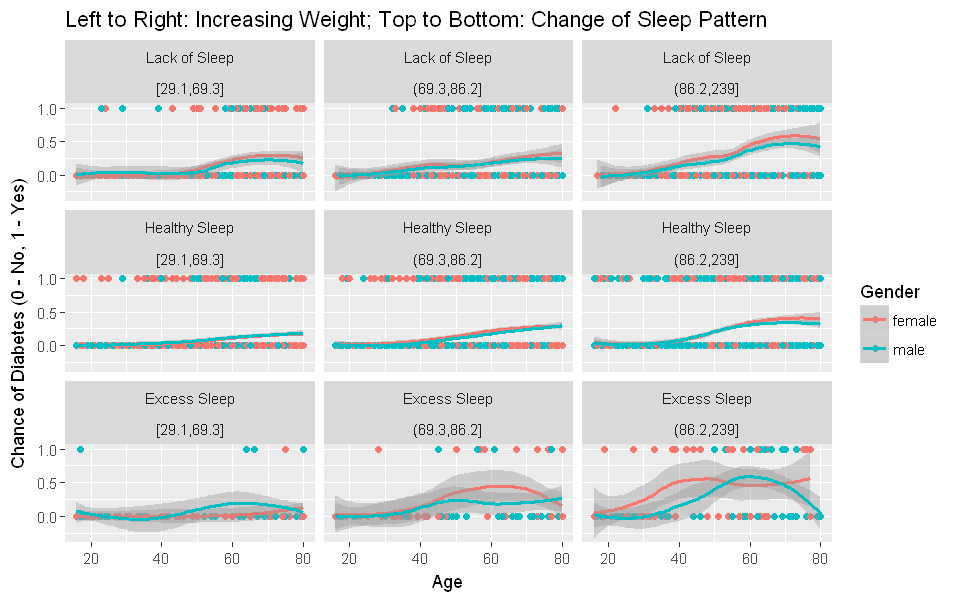

```r
ggplot(Diab2, aes(x = Age, y = Diabetes, color = Gender)) + geom_point() +
geom_smooth(method = "loess") +
facet_wrap(~ SleepHrsNight + ~(cut_number(Weight,n = 3))) +
ggtitle('Left to Right: Increasing Weight; Top to Bottom: Change of Sleep Pattern') +
ylab('Chance of Diabetes (0 - No, 1 - Yes)')
```

It can be clearly observed that the sleep pattern does have a significant impact on people affected with Diabetes.

There is a surprisingly less chance of being diabetic for people of low weight and unhealthy sleep patterns. This could be because of not having enough data points to describe the trend in this region.

The reason for considering weight as an explanatory variable over height is becuase being tall or short does not inherently cause any health disorders but excess or underweight can definitely lead to ill-health.

```r
Diab2.glm = glm(Diabetes ~ Age + Weight + Height + Gender + SleepHrsNight, data = Diab2, family = "binomial")
glm2.grid = expand.grid(Age = seq(10, 80, 10), Height = seq(120, 200, 20),
                    Weight = seq(20, 220, 55),
                    Gender = c("female", "male"),
                    SleepHrsNight = c("Lack of Sleep","Healthy Sleep", "Excess Sleep")  )
Diab2.predict = predict(Diab2.glm, newdata = glm2.grid, type = "response")
Diab2.df = data.frame(glm2.grid, fit = as.vector(Diab2.predict))
```

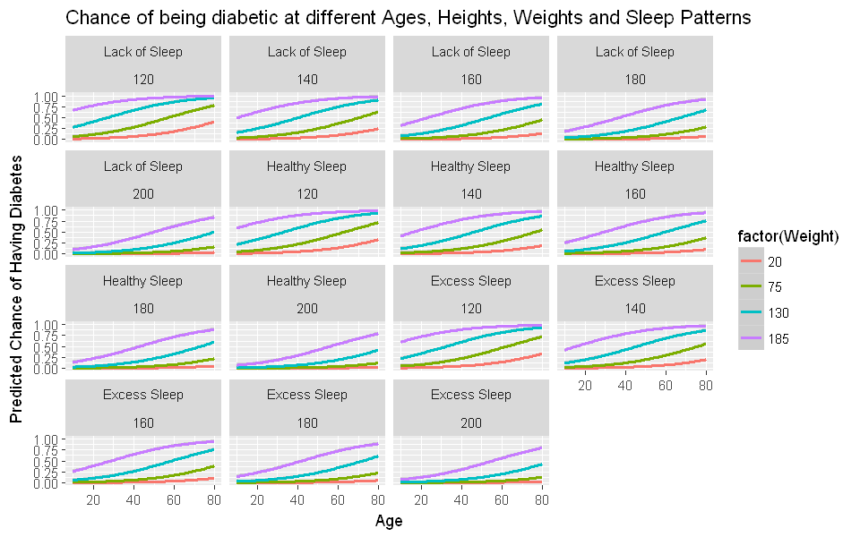

```r
ggplot(Diab2.df, aes(x = Age, y = fit, color = factor(Weight))) + geom_smooth() +
facet_wrap(~ SleepHrsNight + Height) +
ggtitle('Chance of being diabetic at different Ages, Heights, Weights and Sleep Patterns') +
ylab('Predicted Chance of Having Diabetes')
```

As explained in above graphs also, weight plays a more significant role than height in determining the risk of being diabetic. That is probably the reason inspite of healthy sleep, excess weight can be more prone towards being diabetic.